# STA 206 Homework 3

Kevin Su

10/21/2021

# Problem 1

### Part A

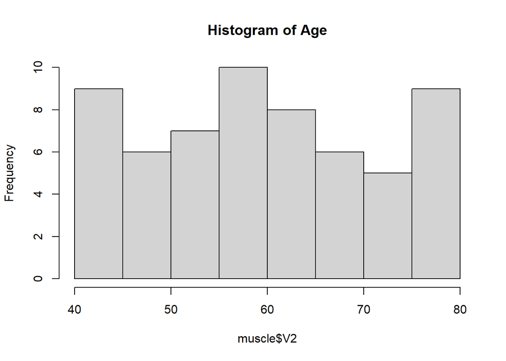

```r
setwd("C:/Users/kevin/Downloads")
muscle <- read.table("muscle.txt")

hist(muscle$V2, main = "Histogram of Age")
```

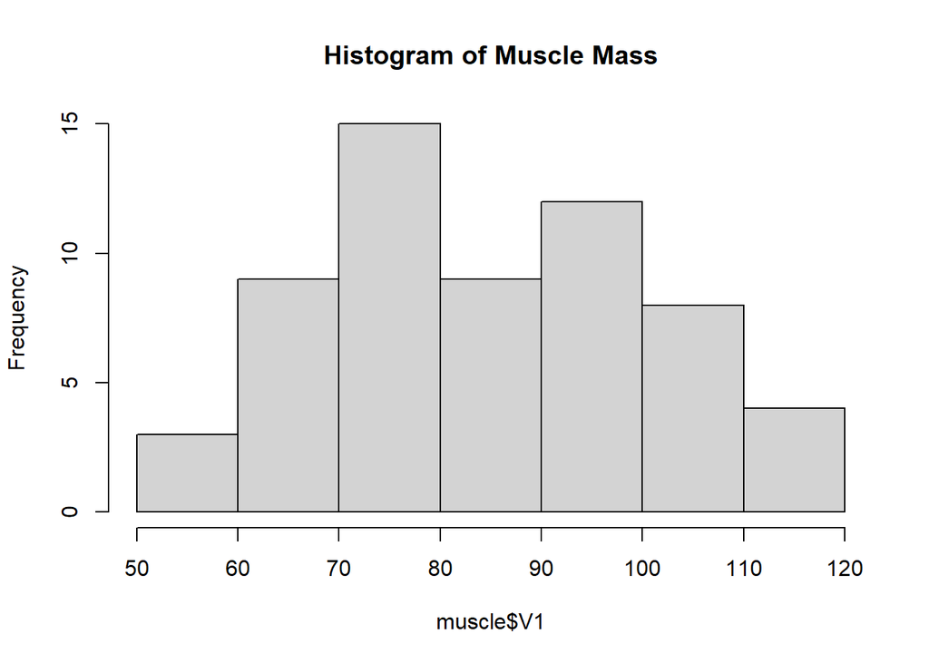

```r
hist(muscle$V1, main = "Histogram of Muscle Mass")
```

The age distribution is roughly uniform between 40 and 80. The distribution of muscle mass seems to be symmetric and centered with mean roughly close to the median between 80 and 90.

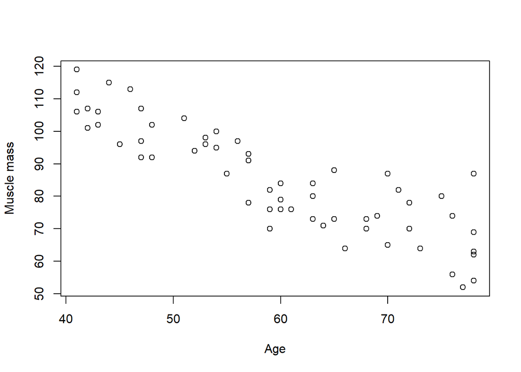

```r
plot(muscle$V2, muscle$V1, xlab = "Age", ylab = "Muscle mass")
```

The scatter plot of muscle mass vs age seems to be roughly linear. The data appears to support the anticipation that the amount of muscle mass decreases with age.

### Part B

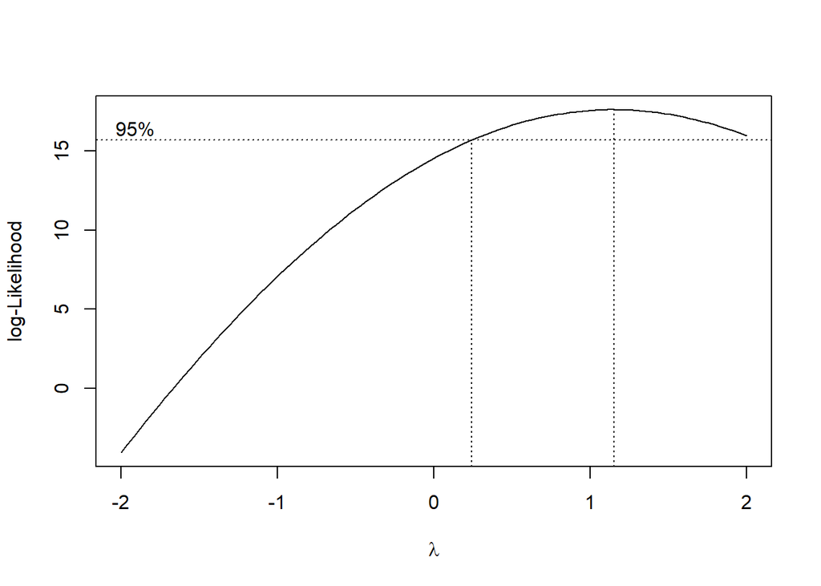

```r
library(MASS)
musclelm <- lm(V1~V2, data = muscle)

boxcox(musclelm)
```

As the 95% confidence interval includes lambda = 1, there is no reason to believe that a transformation of the response variable is necessary.

### Part C

```r
summary(musclelm)
```

```
##
## Call:
## lm(formula = V1 ~ V2, data = muscle)
##
## Residuals:
##      Min       1Q   Median       3Q      Max
## -16.1368  -6.1968  -0.5969   6.7607  23.4731
##
## Coefficients:
##             Estimate Std. Error t value Pr(>|t|)
## (Intercept) 156.3466     5.5123   28.36   <2e-16 ***
## V2           -1.1900     0.0902  -13.19   <2e-16 ***
## ---
## Signif. codes:  0 '***' 0.001 '**' 0.01 '*' 0.05 '.' 0.1 ' ' 1
##
## Residual standard error: 8.173 on 58 degrees of freedom
## Multiple R-squared:  0.7501, Adjusted R-squared:  0.7458
## F-statistic: 174.1 on 1 and 58 DF,  p-value: < 2.2e-16
```

The coefficients are -1.19 for b1 and 156.3466 for b0. Standard errors are 5.5123 for b0, 0.0902 for b1.

```r
anova(musclelm)
```

```
## Analysis of Variance Table
##
## Response: V1
##           Df  Sum Sq Mean Sq F value    Pr(>F)
## V2         1 11627.5 11627.5  174.06 < 2.2e-16 ***
## Residuals 58  3874.4    66.8
## ---
## Signif. codes:  0 '***' 0.001 '**' 0.01 '*' 0.05 '.' 0.1 ' ' 1
```

The MSE is 66.8 with 58 degrees of freedom.

### Part D

The fitted regression line is Yhat = -1.19X + 156.3466

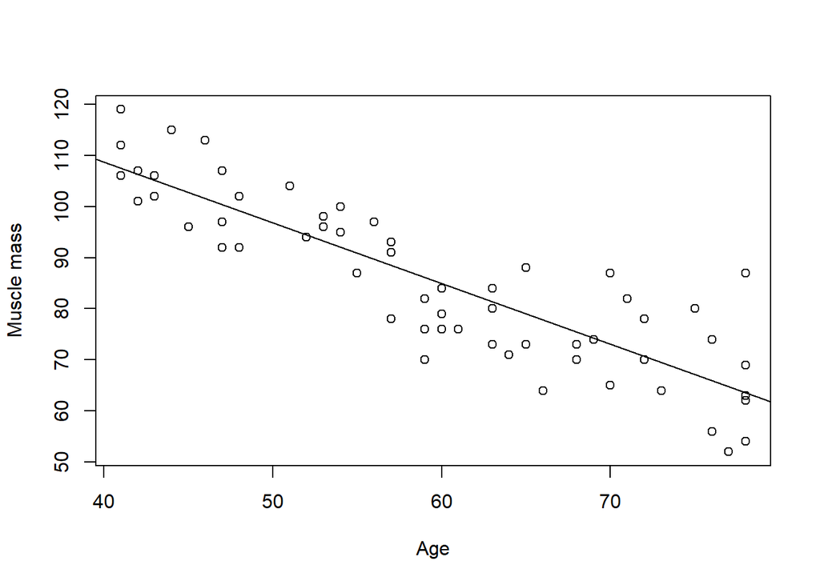

```r
plot(muscle$V2, muscle$V1, xlab = "Age", ylab = "Muscle mass")
abline(musclelm)
```

The fitted line appears to fit the data well.

### Part E

```r
muscle$V2[c(6,16)]
```

```
## [1] 41 55
```

```r
residuals(musclelm)[c(6, 16)]
```

```
##         6        16
## 11.443252 -3.896811
```

```r
fitted.values(musclelm)[c(6,16)]
```

```
##         6        16
## 107.55675  90.89681
```

### Part F

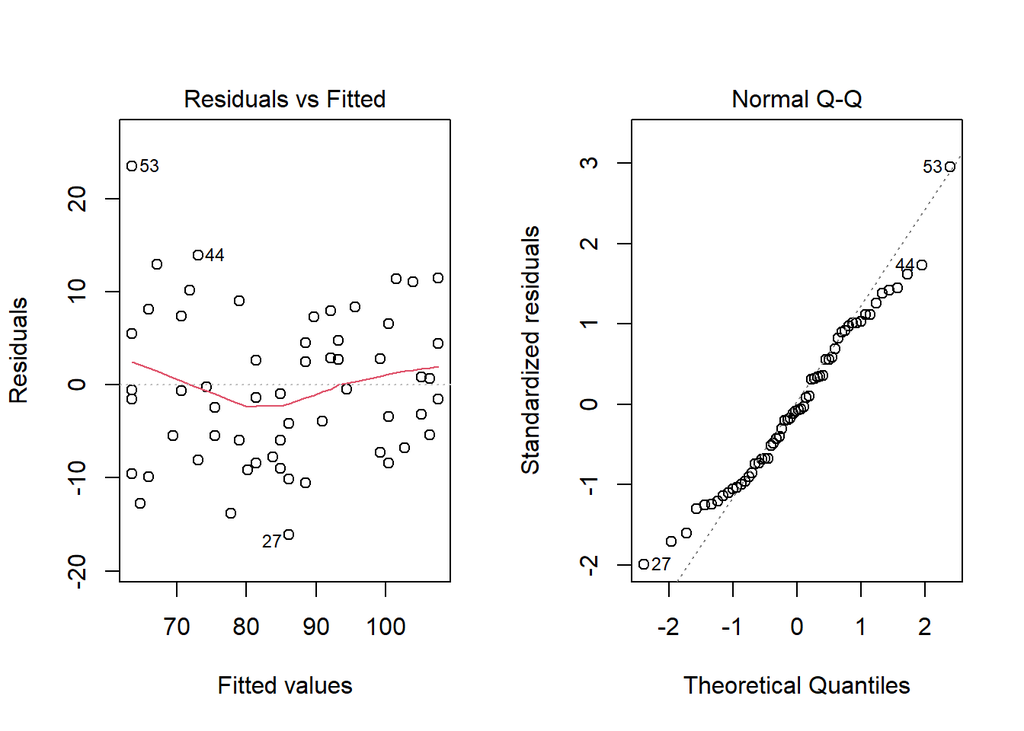

```r
par(mfrow = c(1,2))
plot(musclelm, which = c(1,2))
```

The Residual vs fitted plot does not show a clear nonlinear patter, so there is no reason to believe the assumption of constant variance or linearity is violated. The Normal QQ plot indicates the distribution is rather light-tailed with few extreme values.

### Part G

```r
confint(musclelm, level = 0.99)
```

```
##                  0.5 %      99.5 %
## (Intercept) 141.665827 171.0273010
## V2           -1.430217  -0.9497743
```

We are 99% confident that the intercept lies between 141.665827 and 171.0273010.

### Part H

H0: There is no negative linear association (b1 >= 0) H1: THere is a negative linear association between muscle mass and age (b1 < 0)

Test statistic/expected distribution: t statistic with 58 degrees of freedom.

We reject if t < -2.39.

```r
summary(musclelm)$coefficients
```

```
##               Estimate Std. Error   t value     Pr(>|t|)
## (Intercept) 156.346564 5.51226249  28.36341 1.085415e-35
## V2           -1.189996 0.09019725 -13.19326 4.123987e-19
```

As t = -13.19 < -2.39, we reject the null and conclude there is a negative linear association between muscle mass and age.

### Part I

```r
predict(musclelm, data.frame(V2 = 60), interval = "prediction", level = 0.95)
```

```
##        fit      lwr     upr
## 1 84.94683 68.45067 101.443
```

A given person of age 60 will have muscle mass index between 68.45 and 101.443 with 95% confidence.

### Part J

```r
anova(musclelm)
```

```
## Analysis of Variance Table
##
## Response: V1
##           Df  Sum Sq Mean Sq F value    Pr(>F)
## V2         1 11627.5 11627.5  174.06 < 2.2e-16 ***
## Residuals 58  3874.4    66.8
## ---
## Signif. codes:  0 '***' 0.001 '**' 0.01 '*' 0.05 '.' 0.1 ' ' 1
```

H0: There is no linear association (b1 = 0) H1: There is a linear association between muscle mass and age (b1 != 0)

Test statistic/expected distribution: F statistic with 1 and 58 degrees of freedom.

We reject if F > 7.08.

As F = 174 > 7.08, we reject the null and conclude there is a linear association between muscle mass and age.

### Part K

The proportion of total variation in muscle mass explained by age is R-squared = .7501

The correlation coefficient is the square root of R-squared multiplied by the sign of b1 = -0.866.

```r
summary(musclelm)
```

```
##
## Call:
## lm(formula = V1 ~ V2, data = muscle)
##
## Residuals:
##      Min       1Q   Median       3Q      Max
## -16.1368  -6.1968  -0.5969   6.7607  23.4731
##
## Coefficients:
##             Estimate Std. Error t value Pr(>|t|)
## (Intercept) 156.3466     5.5123   28.36   <2e-16 ***
## V2           -1.1900     0.0902  -13.19   <2e-16 ***
## ---
## Signif. codes:  0 '***' 0.001 '**' 0.01 '*' 0.05 '.' 0.1 ' ' 1
##
## Residual standard error: 8.173 on 58 degrees of freedom
## Multiple R-squared:  0.7501, Adjusted R-squared:  0.7458
## F-statistic: 174.1 on 1 and 58 DF,  p-value: < 2.2e-16
```